# BaseR Recap Biomedical Sciences

# 7 plots

With following functions you can make

- scatter plots (*plot()*)
- histograms (*hist()*)
- boxplots (*boxplot()*)
- barplots (*barplot()*)
- stripcharts (*stripchart()*)

```r
M4 <- matrix(c(2, 5, 5, 3, 4, 3, 4, 9, 10, 7, 3, 3, 4, 4, 7, 4, 2, 3, 9,9 ), nrow = 4, byrow = T)
M4
```

```
##      [,1] [,2] [,3] [,4] [,5]
## [1,]    2    5    5    3    4
## [2,]    3    4    9   10    7
## [3,]    3    3    4    4    7
## [4,]    4    2    3    9    9
```

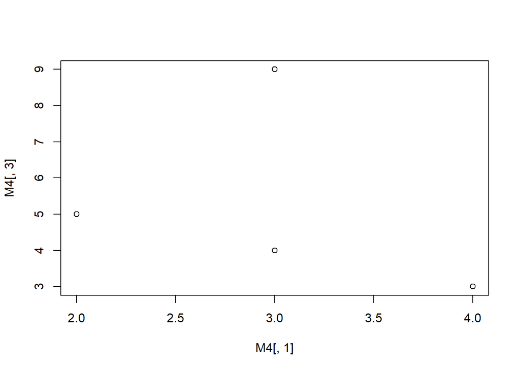

```r
plot(M4[,1], M4[,3]) #plot the values of the first column in x-axis versus these from the third column in the y-axis of a scatter plot
```

You can add legend, points, ablines with following functions: *legend()*, *points()*, *lines()*, *abline()*, *curve()*.

Go to the helpfile of the function *par()*. There you can see which arguments you can add to a plot-function to change plot-points, color of the points, etc…. Some interesting arguments that you can use in the plot function: pch = type of plot-points, col = color of the points, main = give title to plot, xlab = give label to x-axis, etc

Make above plot a bit nicer with x and y labels and colored points…

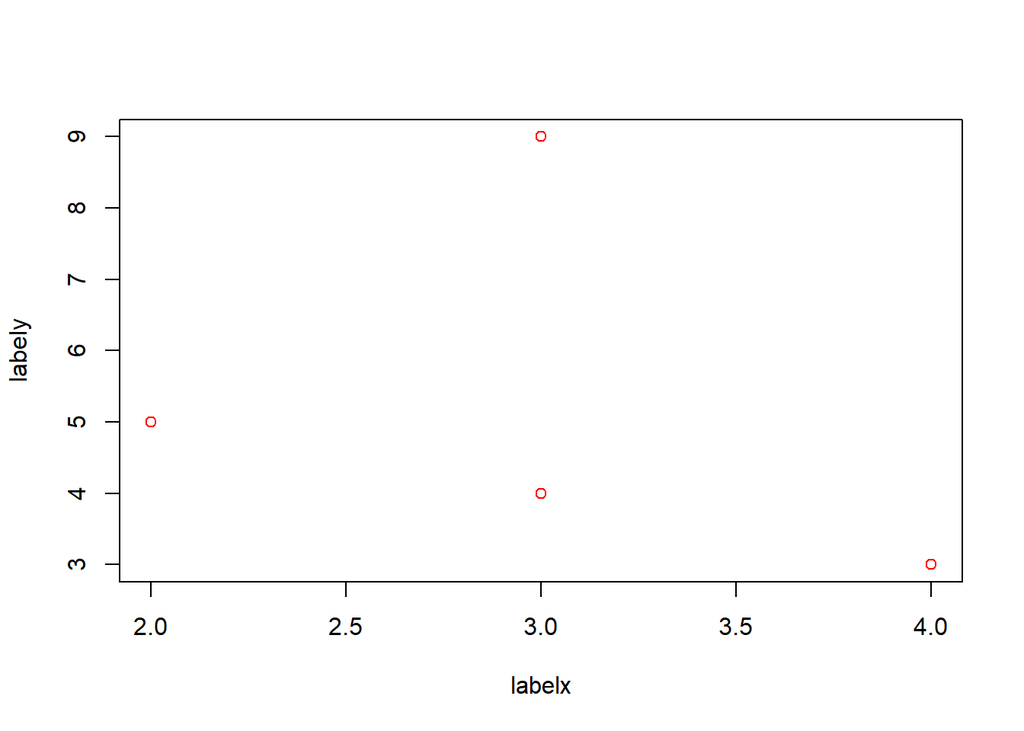

```r
plot(M4[,1], M4[,3], xlab = "labelx", ylab= "labely", col = "red")
```

In a later practical, we will use the package ggplot, which is more flexible and user-friendly.

# 8 read data from and to a text file

If you have generated a matrix in R, you might be interested to export it as a txt file so that you can use it in another program (such as excel, or other). –> export data with write.table

Or you want to apply R-functions on an existing data-matrix that you have as txt-file. –> import/read txt-files with read.table (don’t forget to check that you are in the rigth working directory where your file that you want to import is saved!!!)

Notice the dot after write and read: read. Later we will also see read_ with an underscore.

```r
write.table(M4, file = "export_file.txt") #the matrix M4 will be saved in your working directory in a txt-file named export_file
M_imported <- read.table(file = "export_file.txt") #now we will import the data back into R
```

```r
M_imported # automatically col names are added to the data
```

```
##   V1 V2 V3 V4 V5
## 1  2  5  5  3  4
## 2  3  4  9 10  7
## 3  3  3  4  4  7
## 4  4  2  3  9  9
```

Look at the helpfiles of the functions above. You can see that you can add arguments, for example if the data you want to import have rownames or have a header (= column names), etc. REMARK: if you use read.table data will be read as a data-frame (not as a matrix) (cfr practicum lesson 2)!!!

With the function getwd() you will see in which working directory you are working. You can change it using setwd(). With the function dir() you can see what files are saved under the working directory. So, with dir() you can check whether the file that you would like to import is indeed in your working directory!!! Or you can check if your file is indeed saved.

```r
dir()
```

```
## [1] "3. Exercise on base-R.Rproj" "export_file.txt"
## [3] "Recap_SOLVED_2023.html"      "Recap_SOLVED_2023.Rmd"
## [5] "Recap_SOLVED_2023_files"     "Recap_UNSOLVED_2023.Rmd"
## [7] "RstudioRmarkdownIntro.mp4"   "test.csv"
```

```r
getwd()
```

```
## [1] "C:/Users/abdoj/OneDrive - UGent/Desktop/0. UGent-ABDO/1. Data Intelligence in Sustainable Drug Discovery/5. Prof; De Preter - R practical sessions/0. Introduction to R"
```

# 9 save (the objects) in your current workspace

With the ls-function you can see what objects are all saved/made in the current R-session/workspace/environment. You can save all these objects using the save-function as a .RData file. With load-function you can import the file with all objects again in R. This can be usefull if you want to stop your current R-session (–> use the function save) and re-iterate the analyses at another time (–> use the function load).

```r
ls()
```

```
##  [1] "a"           "add.3.fun"   "b"           "c"           "cha"
##  [6] "cha1"        "cha2"        "com"         "cond"        "d"
## [11] "D"           "df"          "DF"          "fac"         "i"
## [16] "l"           "L"           "lo"          "lo_vec"      "M"
## [21] "M_cha"       "M_imported"  "M_num"       "M1"          "M2"
## [26] "M3"          "M4"          "namesvector" "num"         "num1"
## [31] "num2"        "result_row"  "v"           "vec"         "vec1"
## [36] "vec10"       "vec2"        "vec3"        "vec4"        "vec5"
## [41] "vec6"        "vec7"        "vec8"        "vec9"        "vector2"
## [46] "x"
```

```r
save.image(file = "all_objects_exercises1.RData") # save all objects in the current R-workspace
save(M_imported, M4, file="certain objects of ex1.RData") # save certain objects (1 or more) from your current R-workspace
```

```r
load("all_objects_exercises1.RData")
```

## 9.1 EXERCISE

1. matrix M: plot the expression of gene1 on x-axis versus the expression of gene3 on y-axis. You can save the plot by clicking the rigth mouse button as png file.
2. matrix M: change all expression values with an expression equal to or below 4 to 0,
3. what is the mean expression of all genes in matrix M
4. export the table (matrix M) as a .txt file (name of file = expression data, check directory!).

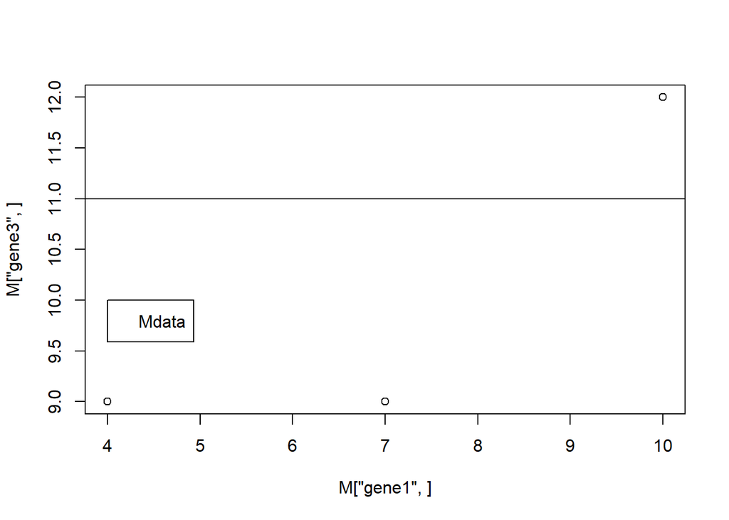

```r
plot(M["gene1", ], M["gene3", ])
abline(h=11) # playing a bit with abline
legend(4, 10, legend="Mdata") # playing a bit with legend
```

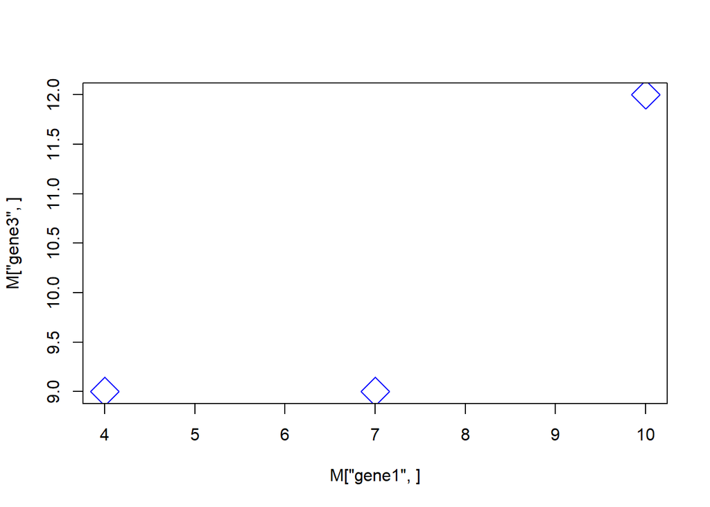

```r
plot(M["gene1",], M["gene3",], col="blue", pch=23, cex=3) # playing a bit with the arguments you can find in ?plot and ?var
```

```r
M[M<=4] <- 0
M
```

```
##       sample1 sample2 sample3
## gene1       0      10       7
## gene2       8       5       7
## gene3       9      12       9
## gene4       0       0       0
```

```r
apply(M, 1, mean)
```

```
##     gene1     gene2     gene3     gene4
##  5.666667  6.666667 10.000000  0.000000
```

```r
write.table(M, file="expression_data.txt")
dir()
```

```
##  [1] "3. Exercise on base-R.Rproj"  "all_objects_exercises1.RData"
##  [3] "certain objects of ex1.RData" "export_file.txt"
##  [5] "expression_data.txt"          "Recap_SOLVED_2023.html"
##  [7] "Recap_SOLVED_2023.Rmd"        "Recap_SOLVED_2023_files"
##  [9] "Recap_UNSOLVED_2023.Rmd"      "RstudioRmarkdownIntro.mp4"
## [11] "test.csv"
```

# 10 Loading R packages

Packages are collections of functions, data sets, and documentation bundled together to provide specific functionality or tools for various tasks. They are a fundamental part of the R ecosystem and play a crucial role in extending R’s capabilities.

There are two important functions when it comes down to R packages:

install.packages(), which as you can expect, installs a given package. library() which loads packages.

## 10.1 tidyverse and tibbles

Tibbles are part of the tidyverse package, so we’ll first need to install and load it. In this course, we’ll mainly use tibbles as a means of manipulating and looking at our data. Tibbles can be seen as data frames and we’ll mostly read them from an external .csv or .tsv file.

```r
#install.packages("tidyverse") #this line only needs to be executed one time. Once the package is installed, you can always load it using the library() function.
library(tidyverse)
```

Alternatively, you can use the require() function, which returns a logical value indicating whether the package was successfully loaded.

```r
if (!require(tidyverse)) {
  install.packages("tidyverse")
  library(tidyverse)
}
```

```r
tibble <- read_csv("test.csv")
tibble
```

```
## # A tibble: 5 × 1
##   `name value1 value2`
##   <chr>
## 1 1 name1 1 0.5
## 2 2 name2 2 0.5
## 3 3 name3 3 0.5
## 4 4 name4 4 0.5
## 5 5 name5 5 0.5
```

The next practical will deal with tidyverse and tibbles in greater detail.